# Practical statistics IV: Time Series Analysis

Hugo Bowne-Anderson, Yale University, Molecular Biophysics & Biochemistry Department

15 January 2016

**These are accompanying notes** for a 4-part ‘Practical Statistics for Experimentalists’ Workshop taught at Yale University in the Fall of 2015, the project of which was to introduce experimentalists to statistical and data analytic methodologies and intuitions that they can immediately use in their everyday work, along with methods to implement everything learned in the R programming language. Participants were Graduate students and Postdoctoral Fellows/Associates from the Molecular Biophysics & Biochemistry Department and Yale Medical School. These notes are not intended as stand-alone resources for ‘Practical Statistics for Experimentalists’, but as supporting material for the Workshop. Having said that, they are relatively complete and give a good indication of what was covered. You will not, however, be able to run all the R code embedded in these notes without the required data sets, many of which were kindly supplied by the relevant scientists/authors. All papers/texts referenced in the body of these notes are listed in the ‘References’ section at the end. Feel free to **contact** me at *hugobowne at gmail dot com* with any questions.

**Workshop IV** is concerned with time series analysis.

# 1 Exploratory Time Series Analysis

## 1.1 Example 1: The energetics of zebrafish embryogenesis

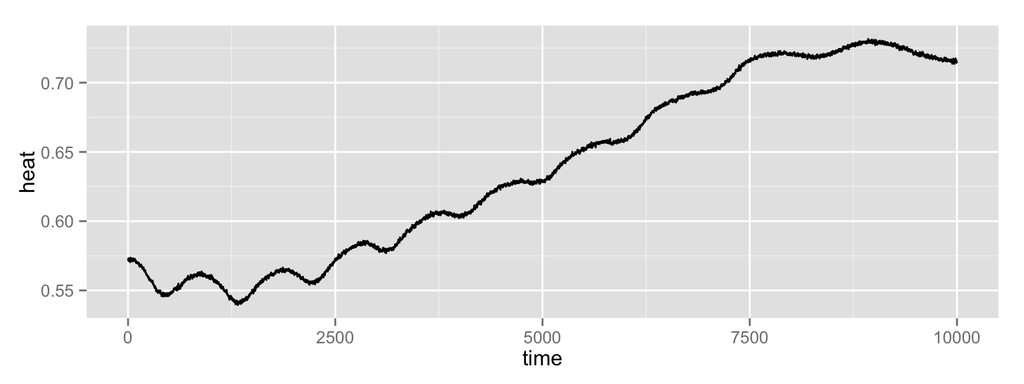

```r
setwd("~/repos/statistical_inference/prac_stats_2016/")
require(ggplot2)
data = read.csv("data/zf_heat_JR.csv")
df = data[1:10000,]
ggplot( df , aes( time , heat )) + geom_line() #+ ylim(0,0.75)
```

```r
#qplot(data$time..sec..[1:10000] , data$heat..ncal.min..[1:10000]) + geom_line()
#exponential.model <- lm(log(df$heat) ~ df$time)
#df$m <- exp(predict(exponential.model,list(df$time)))
#ggplot( df , aes( time , heat )) + geom_line() + geom_line(aes(time,m) , col = 2)
```

**Exercise 1 (~5 minutes)**: Discuss with your neighbours what you see in this time series. Come up with 3 qualities of the data.

# 2 Filtering

As we saw above, to a first order approximation, we can think of a time series as having 3 components: i) a trend, ii) a periodic component & iii) noise/fluctuations. All 3 of us these may be of interest, however the fluctuations are generally of less concern & we would like to more readily see both the trend & the periodic compenent, which together make up the signal. To do so, we’ll need to perform some noise reduction, the first essential examples of which fall under the banner of filtering techniques.

## 2.1 Moving averages & median filters

**Moving average**

Intuitively speaking, a *moving average* reduces the noise in a time series by replacing each point in the series with the (possibly weighted) average of $n$ of its neighbours, for some $n$. The larger theis $n$, the smoother the resulting time series.

**Example**:

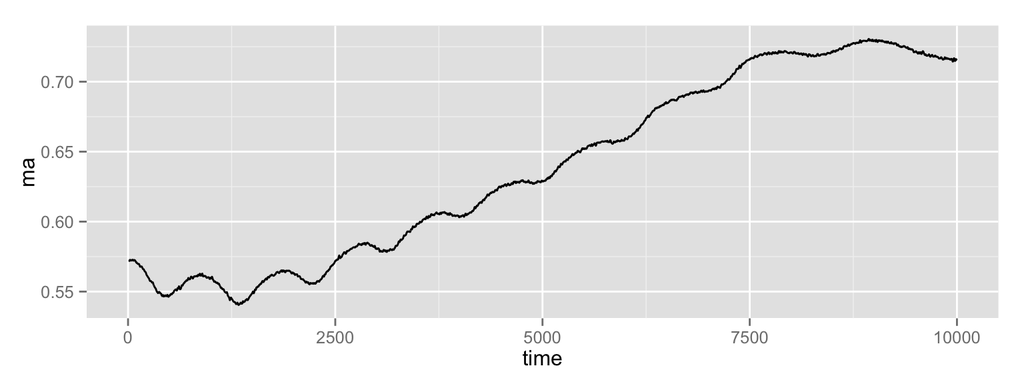

```r
# require(ggplot2)
win_size = 11
df$ma <- filter(df$heat, sides=1, rep(1/win_size,win_size)) # moving average
ggplot( df , aes( time , ma )) + geom_line()
```

```r
#qplot(data$time..sec..[1:10000] , data$heat..ncal.min..[1:10000]) + geom_line()
```

**Exercise 1 (~5 minutes)**: Apply moving average for a variety of window sizes w? What happens as w gets large?

**Median filter**

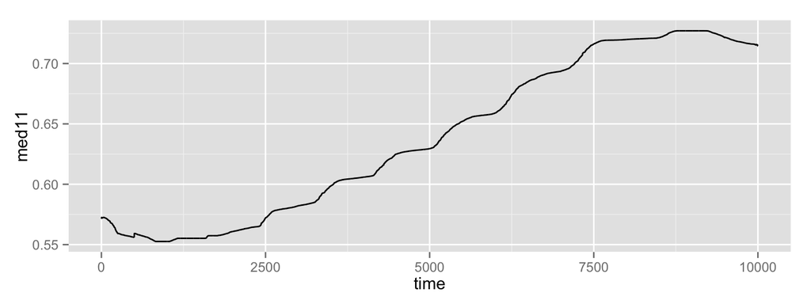

```r
df$med11 <- runmed(df$heat , 1000)
ggplot( df , aes( time , med11 )) + geom_line()
```

p. 48 !

Not so smooth!!

from https://onlinecourses.science.psu.edu/stat510/node/70

‘For non-seasonal series, you aren’t bound to smooth over any particular span. For smoothing you should experiment with moving averages of different spans. Those spans of time could be relatively short. The objective is to knock off the rough edges to see what trend or pattern might be there.’

## 2.2 (First) difference operators ? p. 41

The difference operator is one way to remove trends:

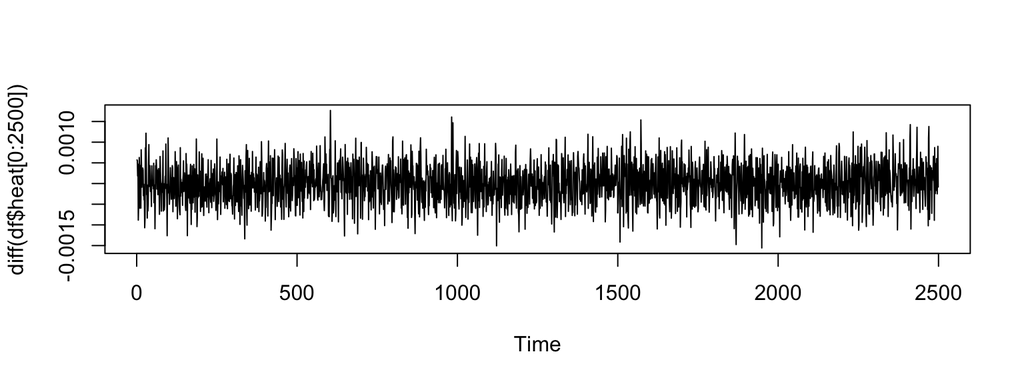

```r
plot.ts(diff(df$heat[0:2500]))
```

## 2.3 Kernel smoothing

## 2.4 Lowess filters

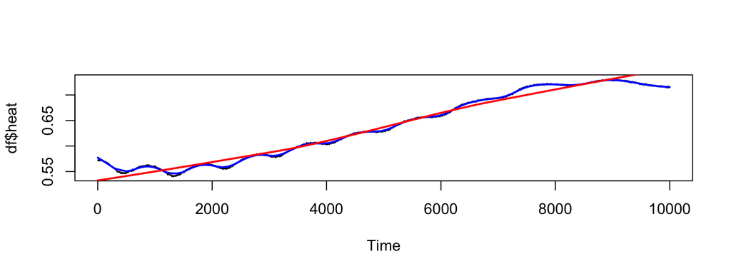

```r
plot.ts(df$heat)
lines(lowess(df$heat, f=.05), lwd=2, col=4) # El Nino cycle
lines(lowess(df$heat), lty=2, lwd=2, col=2) # trend (using default span)
```

The analysis of experimental data that have been observed at different points in time leads to new and unique problems in statistical modeling and inference. The obvi- ous correlation introduced by the sampling of adjacent points in time can severely restrict the applicability of the many conventional statistical methods traditionally dependent on the assumption that these adjacent observations are independent and identically distributed. The systematic approach by which one goes about answer- ing the mathematical and statistical questions posed by these time correlations is commonly referred to as time series analysis. – p.1

The primary objective of time series analysis is to develop mathematical models that provide plausible descriptions for sample data, like that encountered in the previous section. – p.5

# 3 Subtracting the trend

## 3.1 Subtract the moving average:

Do it with ZF:

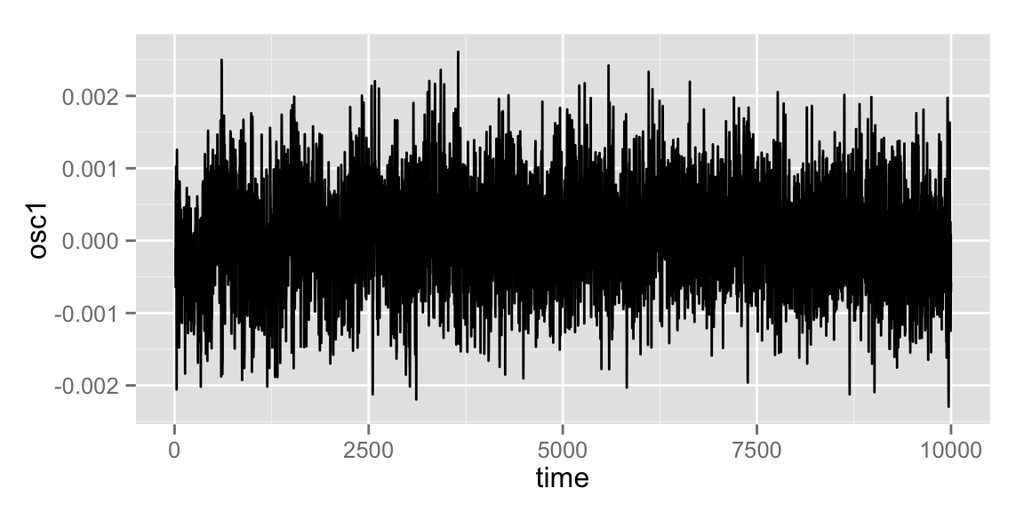

```r
df$osc1 <- df$heat - df$ma
ggplot( df , aes( time , osc1 )) + geom_line()
```

NOT SO GOOD!

Maybe we need to fit a model?

## 3.2 Fitting polynomials

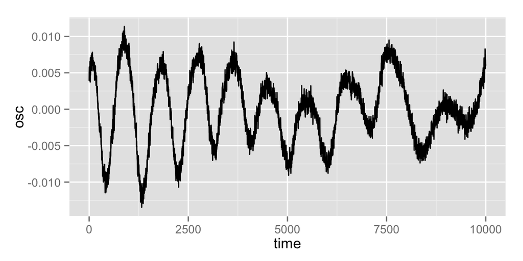

```r
require(pracma)
p <- polyfit( df$time , df$heat , 5)
df$p <- polyval(p, df$time)
#ggplot( df , aes( time , p )) + geom_line() #+ ylim(0,0.75)
df$osc <- df$heat - df$p
ggplot( df , aes( time , osc )) + geom_line() #+ ylim(0,0.75)
```

```r
p
```

```
## [1] -1.666352e-20  3.949145e-16 -3.937932e-12  2.127588e-08 -3.314562e-05
## [6]  5.675245e-01
```

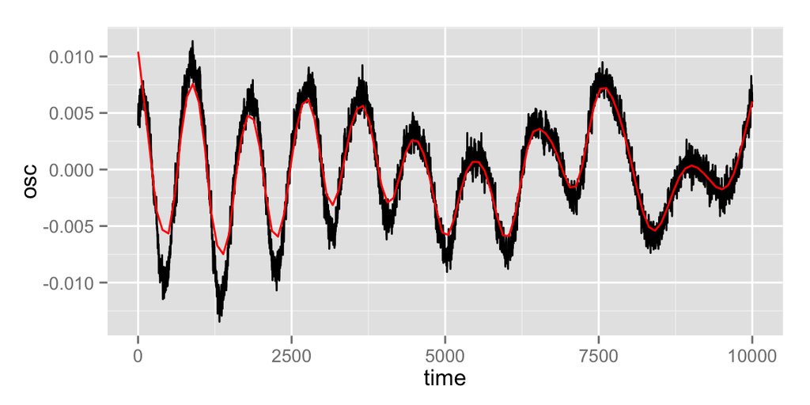

```r
df$osc_lowess <- lowess(df$osc, f=.05)[[2]]
ggplot( df , aes( time , osc)) + geom_line() + geom_line( aes( time , osc_lowess ) , col =2)
```

## 3.3 Fitting models (splines)

Spline = locally polynomial.

```r
df$spline <-spline(df$time , df$heat)
#ggplot( df , aes( time , spline )) + geom_line()
```

Now we have a somewhat periodic signal, that is, one that approximately repeats itself.

Autocorrelation helps us to think about such signals.

# 4 Autocorrelation of time series

## 4.1 Correlation

**Example 1:** scatterplot.

**Example 2:** mRNA + protein (simulated)?

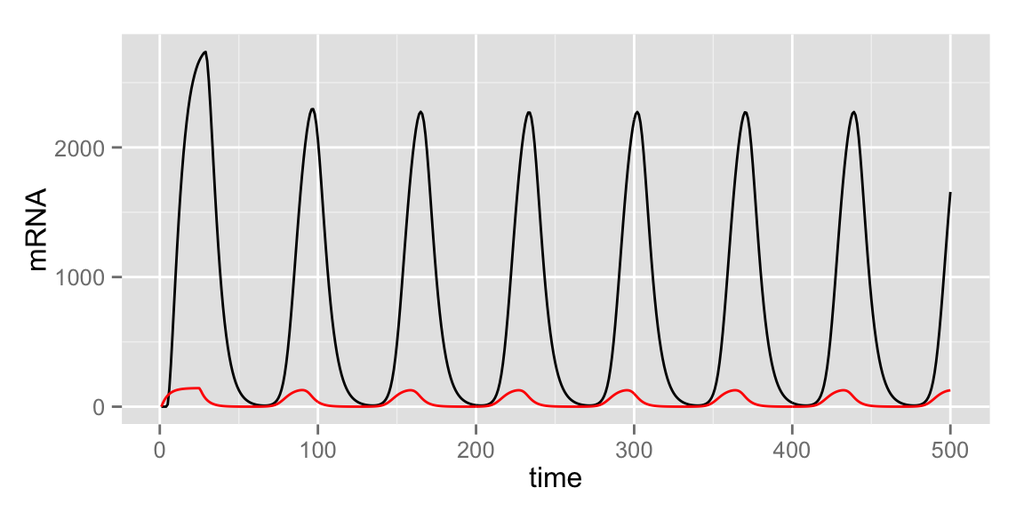

```r
dd <- read.csv("data/genetic_osc_sim.csv")
ggplot( dd[1:500,] , aes(time , mRNA)) + geom_line() + geom_line(aes(time,protein) , col = 2)
```

## 4.2 Correlation of time series

**Example 1:** genetic oscillators?

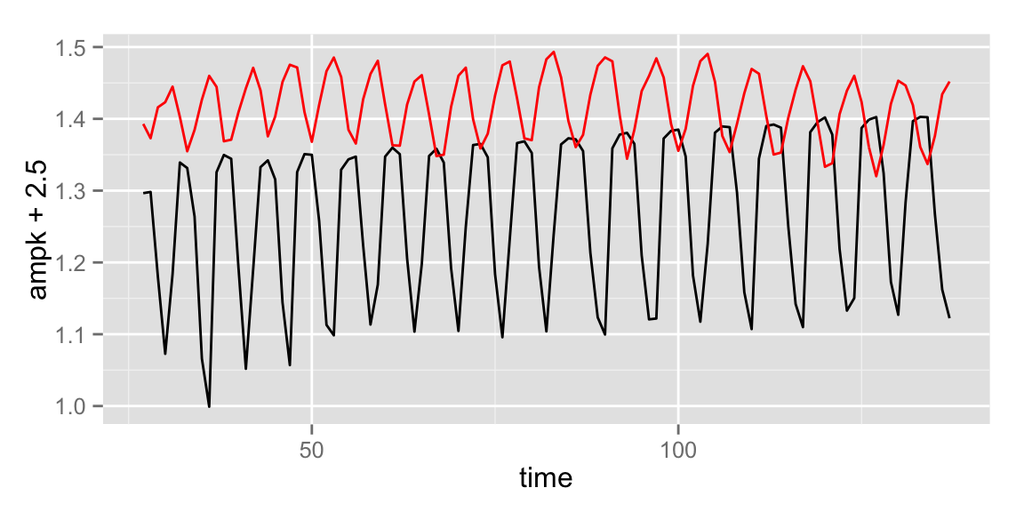

```r
CYratioCyt <- read.csv('CYratioCyt.csv')
rfpCyt <- read.csv('rfpCyt.csv')
rfpNuc <- read.csv('rfpNuc.csv')
ampk=-CYratioCyt
akt=rfpCyt/rfpNuc
ampk$t <- 1:137
akt$t <- 1:137
df1 <- data.frame( 1:137 , ampk$V25 , akt$V25)
colnames(df1) <- c('time' , 'ampk' , 'akt')
df1$akt[1] <- 0
ggplot(df1[27:137,] , aes(time , ampk + 2.5)) + geom_line() + geom_line( aes( time , akt) , col = 2)
```

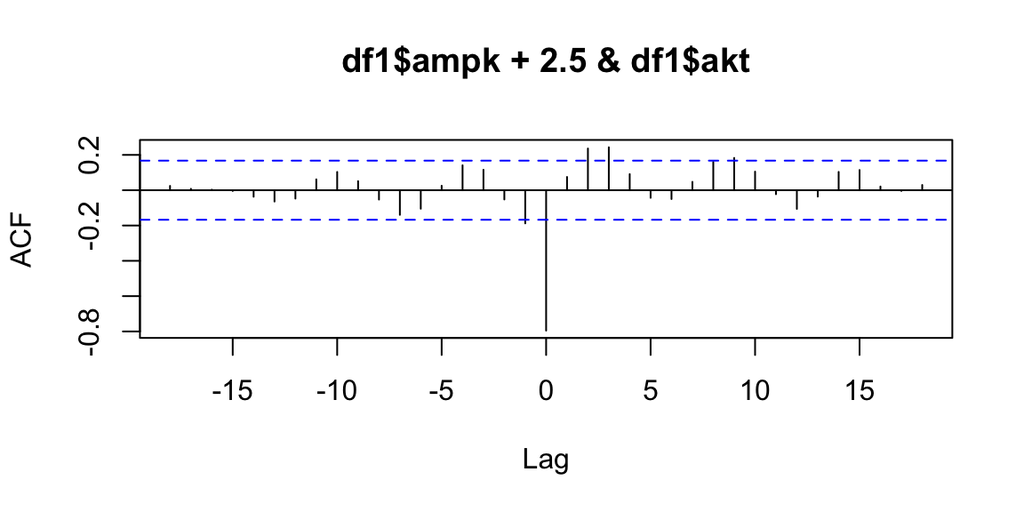

```r
ccf(df1$ampk + 2.5, df1$akt)
```

## 4.3 Autocorrelation of time series

The autocorrelation function (ACF) is

$\rho(s,t) = \frac{\gamma(s,t)}{\sqrt{\gamma(s,s)\gamma(t,t)}}$

The ACF is a special case of the cross-correlation function (CCF).

The autocorrelation function (ACF) of a stationary time series is

$\rho(h) = \frac{\gamma(h)}{\gamma(0)},$

where $\gamma(h) = cov(x_{t+h} , x_t) = E[(x_{t+h} - \mu)(x_t - \mu)]$ is the autocovariance function of a stationary time series.

**Example:** ZF.

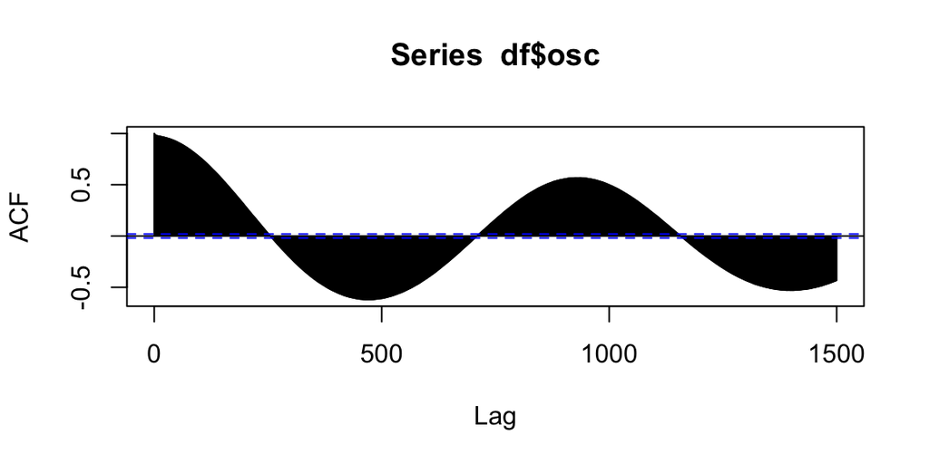

```r
acf(df$osc , lag.max = 1500)
```

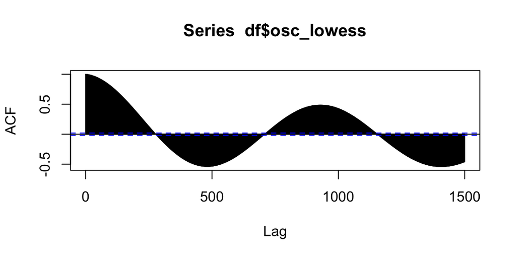

```r
acf(df$osc_lowess , lag.max = 1500)
```

Anything else?

## 4.4 Other examples of autocorrelation of time series

### 4.4.1 White noise

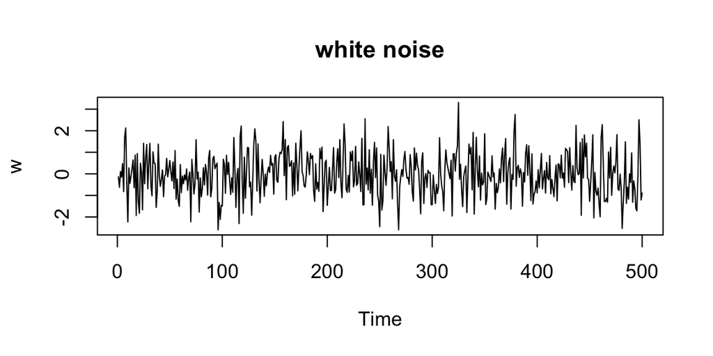

```r
#require(stats)
w = rnorm(500,0,1) # 500 N(0,1) variates
v = filter(w, sides=2, rep(1/3,3)) # moving average
#par(mfrow=c(2,1))
plot.ts(w, main="white noise")
```

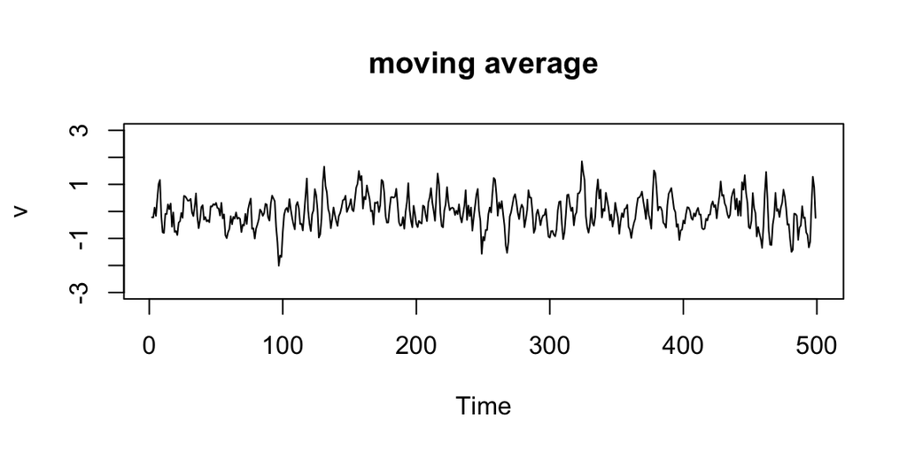

```r
plot.ts(v, ylim=c(-3,3), main="moving average")
```

If the stochastic behavior of all time series could be explained in terms of the white noise model, classical statistical methods would suffice. Two ways of intro- ducing serial correlation and more smoothness into time series models are given in Example 1.7 and Example 1.8. – p.6

### 4.4.2 Brownian motion

### 4.4.3 Random walk with drift

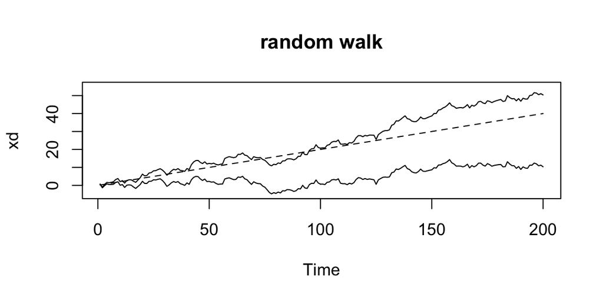

```r
set.seed(154) # so you can reproduce the results
w = rnorm(200,0,1); x = cumsum(w) # two commands in one line
wd = w +.2;   xd = cumsum(wd)
plot.ts(xd, ylim=c(-5,55), main="random walk")
lines(x); lines(.2*(1:200), lty="dashed")
```

# 5 Fourier analaysis

## 5.1 Introduction

Check out this sum of sinusoids:

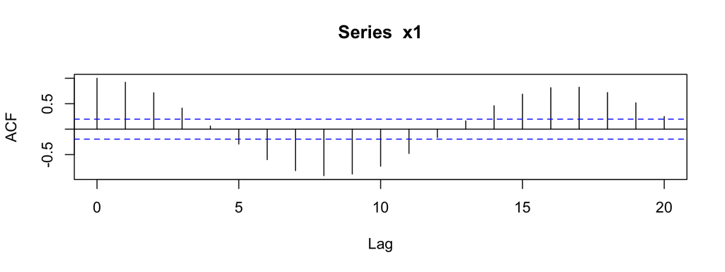

```r
x1 = 2*cos(2*pi*1:100*6/100) + 3*sin(2*pi*1:100*6/100)
acf(x1)
```

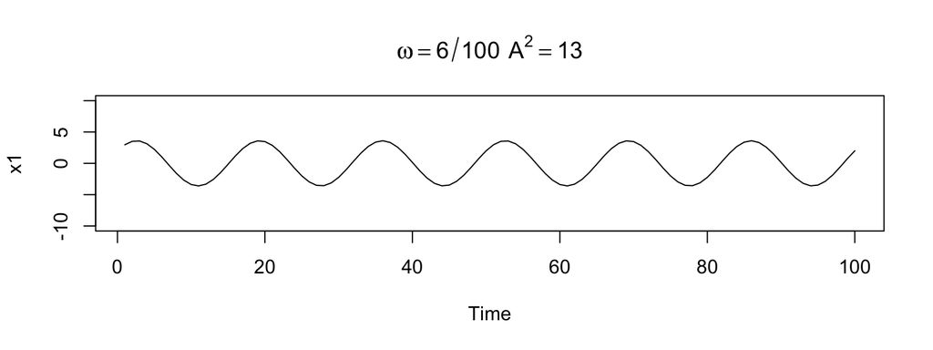

```r
x2 = 4*cos(2*pi*1:100*10/100) + 5*sin(2*pi*1:100*10/100)
x3 = 6*cos(2*pi*1:100*40/100) + 7*sin(2*pi*1:100*40/100)
x = x1 + x2 + x3
#par(mfrow=c(2,2))
plot.ts(x1, ylim=c(-10,10), main=expression(omega==6/100~~~A^2==13))
```

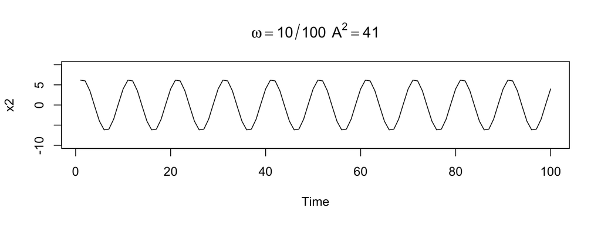

```r
plot.ts(x2, ylim=c(-10,10), main=expression(omega==10/100~~~A^2==41))
```

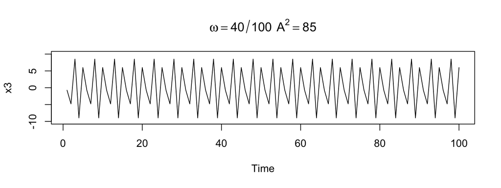

```r
plot.ts(x3, ylim=c(-10,10), main=expression(omega==40/100~~~A^2==85))
```

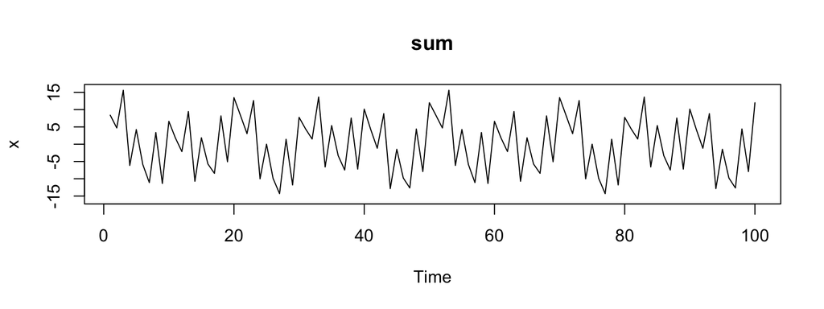

```r
plot.ts(x,  ylim=c(-16,16), main="sum")
```

Look at autocorrelation of these sinusoids :-)

**Essential:** Fourier Theorem.

## 5.2 Fourier analysis

### 5.2.1 Description & set up

```r
#require(signal)
PSD <- function(d){
  n = length(d)
  Per = Mod(fft(d-mean(d)))^2/n
  #Freq = (1:n -1)/n*30000
  return(Per)
}
```

### 5.2.2 Examples

**Example 1:**

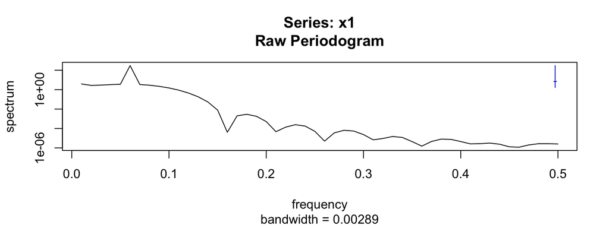

```r
x1 = 2*cos(2*pi*1:100*6/100) + 3*sin(2*pi*1:100*6/100)
spec.pgram(x1) -> xx
```

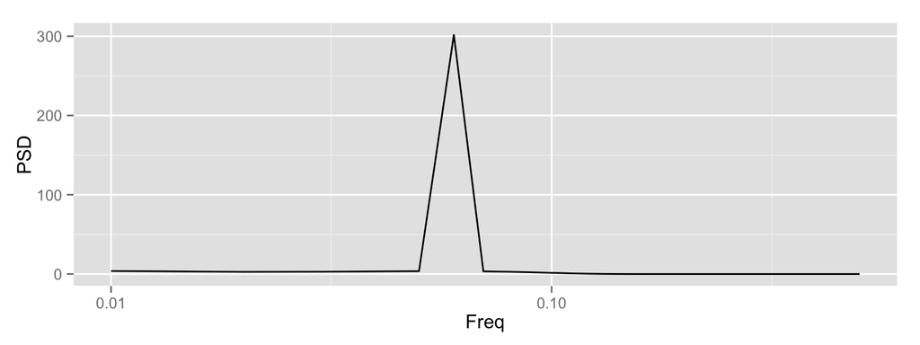

```r
dff2 <- data.frame( xx$spec , xx$freq )
colnames(dff2) <- c("PSD", "Freq")
ggplot( dff2 , aes(Freq , PSD)) + geom_line()+ scale_x_log10()
```

```r
i <- which.max(dff2$PSD)
dom_freq <- dff2$Freq[i]
print(paste('dominant frequency =' , toString(dom_freq)))
```

```
## [1] "dominant frequency = 0.06"
```

**Example 2**: White noise

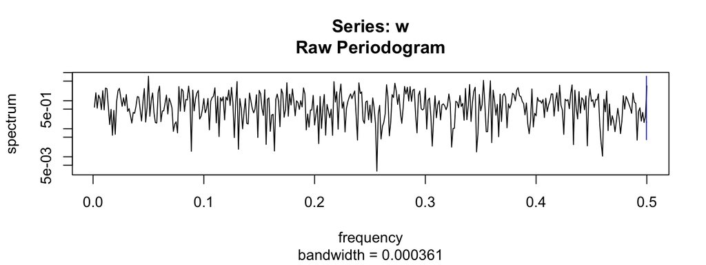

```r
w = rnorm(800,0,1); x = cumsum(w) # two commands in one line
spec.pgram(w) -> xx
```

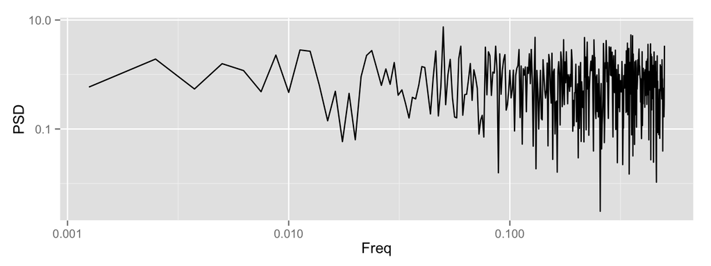

```r
dff2 <- data.frame( xx$spec , xx$freq )
colnames(dff2) <- c("PSD", "Freq")
ggplot( dff2 , aes(Freq , PSD)) + geom_line()+ scale_x_log10() + scale_y_log10()
```

```r
i <- which.max(dff2$PSD)
dom_freq <- dff2$Freq[i]
print(paste('dominant frequency =' , toString(dom_freq)))
```

```
## [1] "dominant frequency = 0.05"
```

**Example 3:** Zebrafish energetics

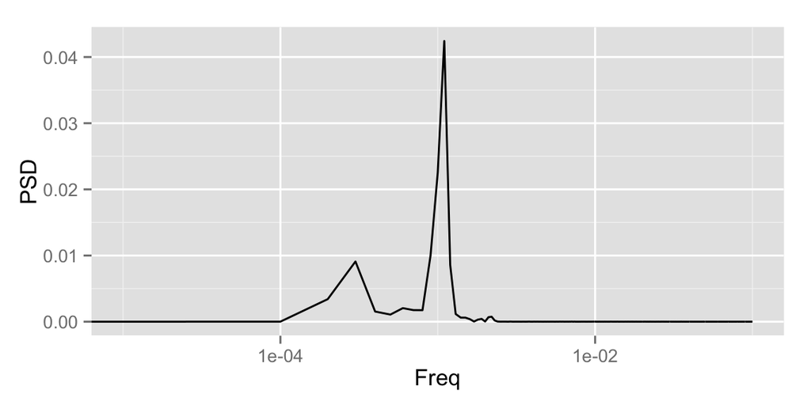

```r
n = length(df$osc)
Freq = (1:n -1)/n
psd <- PSD(df$osc)
dff <- data.frame( psd , Freq )
colnames(dff) <- c("PSD", "Freq")
ggplot( dff , aes(Freq , PSD)) + geom_line()+ scale_x_log10(limits = c(1e-5 , 1e-1))
```

```r
i <- which.max(dff$PSD)
dom_freq <- dff$Freq[i]
print(paste('dominant frequency =' , toString(dom_freq)))
```

```
## [1] "dominant frequency = 0.0011"
```

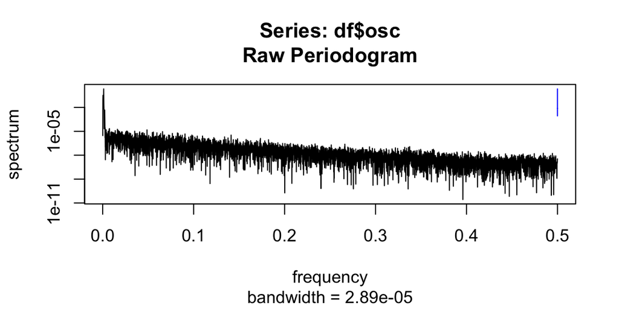

```r
spec.pgram(df$osc) -> xx
```

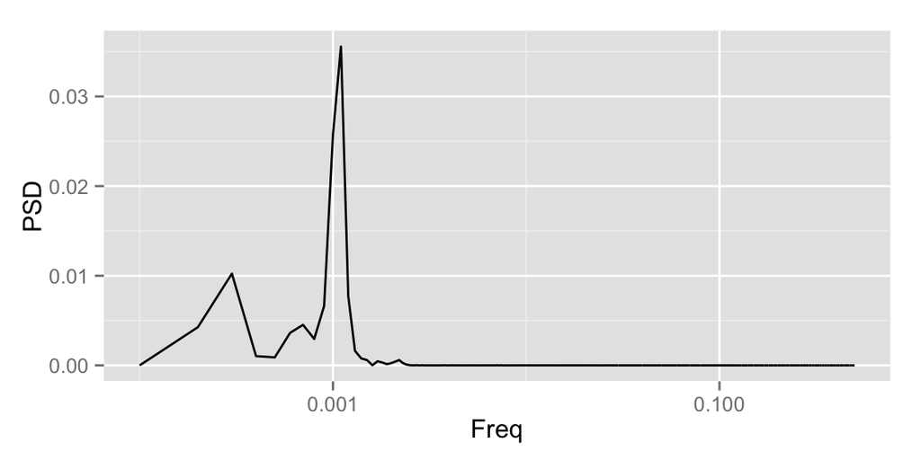

```r
dff2 <- data.frame( xx$spec , xx$freq )
colnames(dff2) <- c("PSD", "Freq")
ggplot( dff2 , aes(Freq , PSD)) + geom_line()+ scale_x_log10()
```